# Dynamic Reporting mit "knitr" & RStudio

Guido Schulz  
28.10.2015

### Probleme der "Common Practice"

- **Fehleranfälligkeit** bei “Handarbeit”
- **Hoher Aufwand** (z.B. Tabelle in LaTex manuell auffüllen)
- **Workflow kaum nachvollziehbar** (v.A. GUI Software) –> schwer reproduzierbar
- Kleinste Änderungen der Datenquelle erfordern **Wiederholung von Arbeit**
- Von einander **getrennete Analyse- & Schreibprozesse** müssen synchronisiert werden

### Lösung: Dynamic Reporting

- Dynamic Document (= Source):

Computer Code + Narrative

- Dynamic Document ===knitr===> Report

[figure not shown]

### Dynamic Reporting mit "knitr"

**Beispiele:**

- *R + LaTex ===knitr===> .pdf*
- *R + Markdown ===knitr===> .hmtl*
- *Python + Markdown ===knitr===> .docx*
- *.etc*

### "knitr" Minimalbeispiel

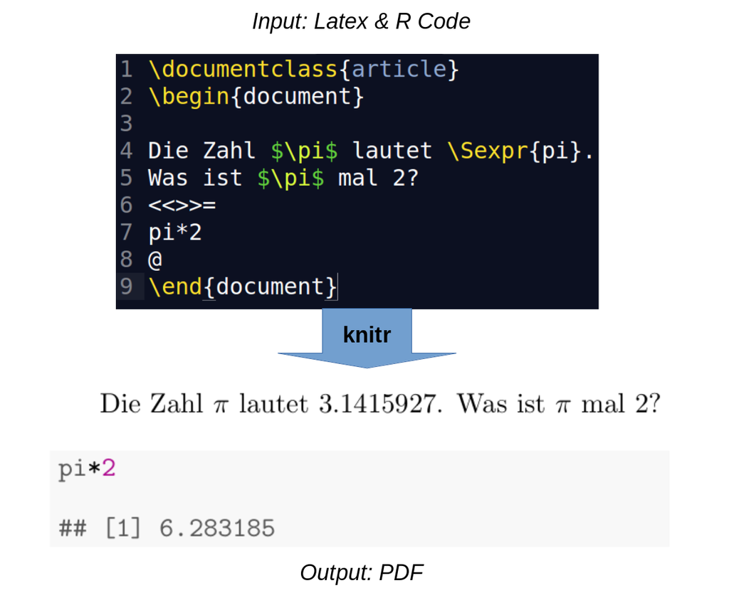

### Reproducible Research (RR)

**RR:**

*Research results are replicable if there is sufficient information available for independent researchers to make the same findings using the same procedures* (King, 1995).

**Really RR:**

*The data and code used to make a finding are available and they are sufficient for an independent researcher to recreate the finding* (Peng, 2011).

### Vorteile des RR

**Allgemein:**

- Standard wissenschaftlicher Behauptungen
- Verhinderung von “Doppelter Arbeit”
- Förderung kumulativer Wissensproduktion

**Individuell:**

- Bessere Arbeitsgewohnheiten
- Vereinfacht Teamwork
- Vereinfacht das Vornehmen von Änderungen
- Höherer Research Impact

### RR & Dynamic Reporting

RR *kann* ein Nebenprodukt von Dynamic Reporting sein, *muss* aber nicht!

- **Good Practice:**
  - Relative Pfadangaben
  - Automatisierung aller Arbeitsschritte, etc.
- **Probleme beim RR:**
  - Daten zu groß
  - Datenschutz
  - Software Version & Konfiguration, etc.

### Nachteile

- **Debugging** kompliziert
- Manchmal **Konflikte zwischen LaTex Paketen & knitr** (z.B. Bibliographie)
- Manchmal **Layoutprobleme** (z.B. Schriftgröße in Plots)
- Bisher **keine umfassenden knitr Lösungen** (z.B. fehlende Unterstützung zur Darstellung spezieller Regressionsmodelle)

### Hilfreiche Literatur rund um "knitr"

**Einführende Tutorials:**

- [knitr in a knutshell](http://kbroman.org/knitr_knutshell/pages/overview.html) (Karl Broman)
- [Einführung in knitr](http://www.dante.de/events/dante2014/Programm/Vortraege/mertens.pdf) (Ulf Mertens)

**Ausführliches Begleitbuch & Dokumentation:**

- [Dynamic Documents with R and knitr (2nd Ed.)](https://www.crcpress.com/Dynamic-Documents-with-R-and-knitr-Second-Edition/Xie/9781498716963) (Yihui Xie)
- [knitr Website](http://yihui.name/knitr/) (Yihui Xie)

### Alle Beispieldokumente

Den Sourcecode dieser Präsentation & aller besprochenen Beispiele findet ihr auf:

github.com/chamaoskurumi/Einfuehrung_in_knitr